# Assignment 1 - The tidyverse

siddharth-padmanabhan

September 26, 2022 | 22:13:40 | CEST

```r
library(haven)
library(tidyr)
library(dplyr)
library(legislatoR)
library(tibble)
library(descr)
library(ggplot2)
library(magrittr)
library(lubridate)
```

### Getting started with the Comparative Legislators Database

The Comparative Legislators Database (CLD) includes political, sociodemographic, career, online presence, public attention, and visual information for over 45,000 contemporary and historical politicians from ten countries (see the [corresponding article](https://www.cambridge.org/core/journals/british-journal-of-political-science/article/comparative-legislators-database/D28BB58A8B2C08C8593DB741F42C18B2) for more information). It can be accessed via `legislatoR` - an R package that is available on both [CRAN](https://cran.r-project.org/web/packages/legislatoR/index.html) and [GitHub](https://github.com/saschagobel/legislatoR).

Before you start with the following tasks, skim the tutorial to make yourself familiar with the database. You find it [here](https://cran.r-project.org/web/packages/legislatoR/vignettes/legislatoR.html).

For the following tasks, you will work with ONE of the legislatures. The legislature you’ll work with depends on your first name:

| Your first name starts with… | Legislature | Code |
| --- | --- | --- |
| A-C | Austrian Nationalrat | `aut` |
| D-F | Canadian House of Commons | `can` |
| G-I | Czech Poslanecka Snemovna | `cze` |
| J-L | Spanish Congreso de los Diputados | `esp` |
| M-O | French Assemblée | `fra` |
| P-R | German Bundestag | `deu` |
| S-U | Irish Dail | `irl` |
| V-X | UK House of Commons | `gbr` |
| Y-Z | US House of Representatives | `usa_house` |

The following tasks will be based on data from the `core` and `political` tables of the database.

### Task 1 - Descriptives [8 points in total]

1. What’s the overall share of male legislators in the entire dataset? [1 point]

```r
#legislatoR::cld_content()
coredf <- get_core(legislature = "irl")
poldf <- get_political(legislature = "irl")

#coredf %>% count(sex)

coredf_a <- coredf[!is.na(coredf$sex), ]

coredf_a %>%
    group_by(sex) %>%
    summarise(Count = n(), Percent = round(((n()/nrow(coredf_a))*100),2) )
```

| sex | Count | Percent |
| --- | --- | --- |
| female | 132 | 9.4 |
| male | 1272 | 90.6 |

```r
#There's a total of 1408 observations for legislators in the dataset, but 4 of them had invalid or unavailable information about the 'sex' variable. Therefore, we reduce it to 1404 observacations and arrive at the above table.
```

2. How many (both in absolute and relative terms) legislators died in the same place they were born in? [1 point]

```r
coredf_b <- coredf[!is.na(coredf$birthplace), ]
coredf_b <- coredf_b[!is.na(coredf_b$deathplace), ]

coredf_b %>% mutate(sameplace = ifelse(coredf_b$birthplace == coredf_b$deathplace, "Same Place", "Different places")) %>%
  group_by(sameplace) %>%
  summarise(Count = n()) %>%
  mutate(percent = round(((Count/sum(Count))*100),2))
```

| sameplace | Count | percent |
| --- | --- | --- |
| Different places | 130 | 75.58 |
| Same Place | 42 | 24.42 |

```r
#We eliminate the NAs for the key variables here: birthplace and deathplace, but that removes a significant portion of the dataset and we are left with only 172 observations. The remaining observations are displayed in the above table.
```

3. Create a new variable `age_at_death` that reports the age at which legislators died. Then, plot the distribution of that variable for the entire dataset. [2 points]

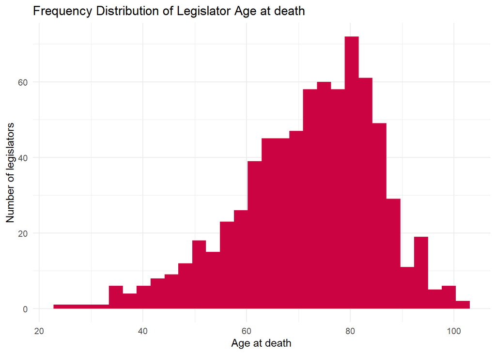

```r
coredf_c <- coredf[!is.na(coredf$birth), ]
coredf_c <- coredf_c[!is.na(coredf_c$death), ]

coredf_c <- coredf_c %>%
  mutate(age_at_death = (coredf_c$death - coredf_c$birth)/365) %>%
  filter(age_at_death>=0)

coredf_c %>%
  ggplot(aes(x = age_at_death)) +
  geom_histogram(bins = 30, fill = "#cc0343") +
  labs(title = "Frequency Distribution of Legislator Age at death",
       x = "Age at death",
       y = "Number of legislators") +
  theme_minimal()
```

4. What is the most frequent birthday in your sample (e.g., “January 15”)? [2 points]

```r
coredf_d <- coredf[!is.na(coredf$birth), ]

freq_hbd <-
  function(birthdata) {
  uniquehbd <- unique(birthdata)
  tab <- tabulate(match(birthdata, uniquehbd))
  uniquehbd[tab == max(tab)]
  }

freq_hbd(coredf_d$birth)
```

```
[1] "1900-01-01 UTC"
```

```r
#The most frequent birthday in the sample, January 1st, 1900, is displayed above by finding the mode of the birthdates information.
```

5. Generate a table that provides the 5 legislators with the longest names (in terms of number of characters, ignoring whitespace). [2 points]

```r
coredf$namelength <- nchar(coredf$name)

coredf %>%
  arrange(desc(namelength)) %>%
  slice(1:5)
```

|  | country | pageid | wikidataid | wikititle | name | sex | ethnicity | religion | birth | death | birthplace | deathplace | namelength |
| --- | --- | --- | --- | --- | --- | --- | --- | --- | --- | --- | --- | --- | --- |
| 464 | IRL | 9632878 | Q6759291 | Margaret_Collins-O'Driscoll | Margaret Collins-O'Driscoll | female | NA | NA | 1878-01-01 | 1945-06-17 | NA | NA | 27 |
| 1990 | IRL | 5205701 | Q6835558 | Michael_ffrench-O'Carroll | Michael ffrench-O'Carroll | male | NA | NA | 1919-09-15 | 2007-05-05 | NA | NA | 25 |
| 4678 | IRL | 31043154 | Q6756353 | Marcella_Corcoran_Kennedy | Marcella Corcoran Kennedy | female | white | NA | 1963-01-07 |  | 51.50722,-0.1275 | NA | 25 |
| 123 | IRL | 50342613 | Q24053519 | Jennifer_Murnane_O'Connor | Jennifer Murnane O'Connor | female | NA | NA | 1966-05-24 |  | 52.66667,-6.83333 | NA | 25 |
| 341 | IRL | 63068592 | Q84732712 | Jennifer_Carroll_MacNeill | Jennifer Carroll MacNeill | female | NA | NA | 1980-09-05 |  | 53.3425,-6.26583 | NA | 25 |

### Task 2 - Exploring trends in the data [8 points in total]

1. Using data from all sessions, provide a plot that shows the share of male legislators by session! [3 points]

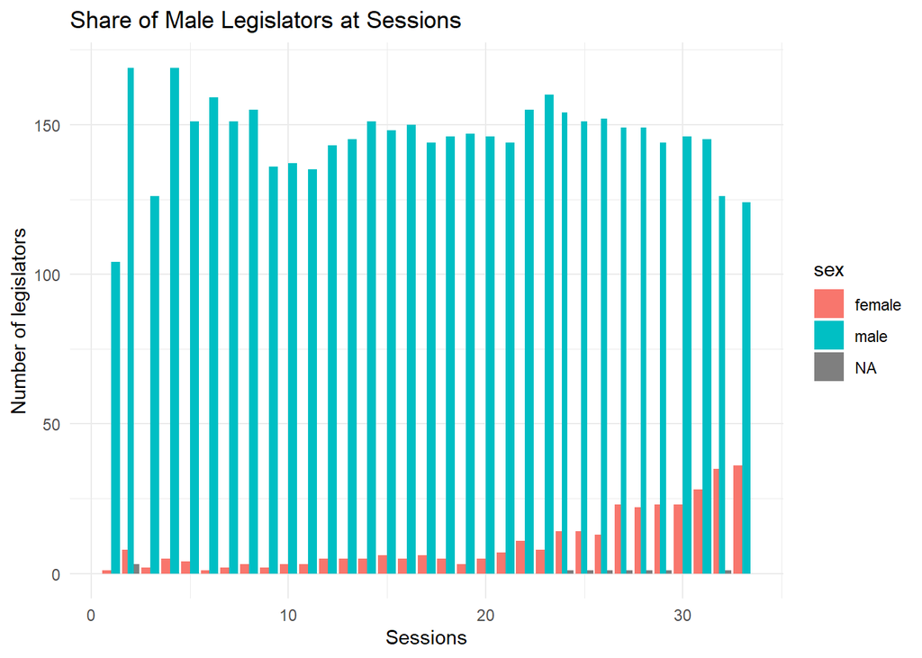

```r
coredf_2a <- coredf[!is.na(coredf$sex), ]

coredf_2a <- coredf_2a %>% mutate(pageid = as.numeric(pageid))
poldf_2a <- poldf %>% mutate(pageid = as.numeric(pageid))

combdf <-
  left_join(poldf_2a,
            coredf_2a %>% dplyr::select(pageid, sex, name),
            by = "pageid")

ggplot(combdf, mapping = aes(x = session)) +
        geom_bar(aes(fill = sex),
                  position = "dodge") +
    labs(title = "Share of Male Legislators at Sessions",
       x = "Sessions",
       y = "Number of legislators") +
  theme_minimal()
```

2. Explore another relation of variables in the dataset. Your analysis should (i) use data from both the `core` and the `political` table and (ii) feature data from several sessions. Also, offer a brief description and interpretation of your findings! [5 points]

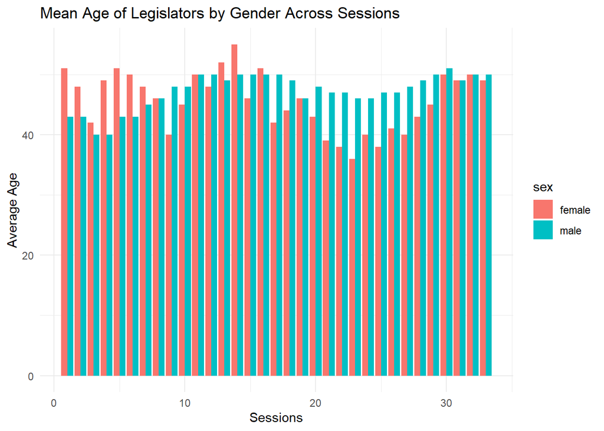

```r
coredf_2b <- coredf[!is.na(coredf$sex), ]

combidf <-
  left_join(poldf,
            coredf_2b %>% dplyr::select(pageid, birth,sex),
            by = "pageid")

combidf$birth_date <- as.Date(combidf$birth)
#class(combidf$birth_date)
combidf$session_start_date <- as.Date(combidf$session_start)
#class(combidf$session_start_date)

combidf <- combidf %>%
  mutate(age_session = round((combidf$session_start_date - combidf$birth_date)/365))

combidf$age_session <- as.numeric(combidf$age_session)

finaldf <- combidf %>%
  group_by(session,sex) %>%
  summarize(mean_age = round(mean(age_session, na.rm = T)), .groups = 'drop') %>%
  drop_na()

#finaldf %>% pivot_wider(names_from=sex, values_from=mean_age)

ggplot(data=finaldf,
       aes(x=session, y=mean_age, fill=sex)) +
    geom_bar(stat="identity", position=position_dodge()) +
   labs(title = "Mean Age of Legislators by Gender Across Sessions",
       x = "Sessions",
       y = "Average Age") +
  theme_minimal()
```

We analyse the mean age of legislators by gender, across all the sessions. We see that in the earlier sessions, the average age of women was typically higher than that of the men. From around session 15 onwards, this trend is reversed and the mean age of the men is higher for most of the rest of the data set. Around session 30, though, parity is restored and the mean age seem to be quite close to each other.